# Compito 01 Feb 2017

Emanuele Lena - 142411@uniud

1/2/2022

```r
knitr::knit('Funzioni.Rmd')
```

```
##
##
## processing file: Funzioni.Rmd
```

[output not shown]

```
## output file: Funzioni.md
```

```
## [1] "Funzioni.md"
```

# Compito del 1 febbraio 2017

```
## starting httpd help server ... done
```

Describe how to perform a preliminary data analysis on this dataframe, using suitable R commands.

## EDA

```r
nrow(mtcars)
```

```
## [1] 32
```

```r
summary(mtcars)
```

```
##       mpg             cyl             disp             hp
##  Min.   :10.40   Min.   :4.000   Min.   : 71.1   Min.   : 52.0
##  1st Qu.:15.43   1st Qu.:4.000   1st Qu.:120.8   1st Qu.: 96.5
##  Median :19.20   Median :6.000   Median :196.3   Median :123.0
##  Mean   :20.09   Mean   :6.188   Mean   :230.7   Mean   :146.7
##  3rd Qu.:22.80   3rd Qu.:8.000   3rd Qu.:326.0   3rd Qu.:180.0
##  Max.   :33.90   Max.   :8.000   Max.   :472.0   Max.   :335.0
##       drat             wt             qsec             vs
##  Min.   :2.760   Min.   :1.513   Min.   :14.50   Min.   :0.0000
##  1st Qu.:3.080   1st Qu.:2.581   1st Qu.:16.89   1st Qu.:0.0000
##  Median :3.695   Median :3.325   Median :17.71   Median :0.0000
##  Mean   :3.597   Mean   :3.217   Mean   :17.85   Mean   :0.4375
##  3rd Qu.:3.920   3rd Qu.:3.610   3rd Qu.:18.90   3rd Qu.:1.0000
##  Max.   :4.930   Max.   :5.424   Max.   :22.90   Max.   :1.0000
##        am              gear            carb
##  Min.   :0.0000   Min.   :3.000   Min.   :1.000
##  1st Qu.:0.0000   1st Qu.:3.000   1st Qu.:2.000
##  Median :0.0000   Median :4.000   Median :2.000
##  Mean   :0.4062   Mean   :3.688   Mean   :2.812
##  3rd Qu.:1.0000   3rd Qu.:4.000   3rd Qu.:4.000
##  Max.   :1.0000   Max.   :5.000   Max.   :8.000
```

- mpg, disp, hp, drat, wt, qsec sono certamente variabili numeriche continue;
- vs, am sono variabili categoriali binarie;

```r
mtcars2 <- mtcars
mtcars2$vs <- factor(mtcars2$vs, labels = c("automatic", "manual"))
mtcars2$am <- factor(mtcars2$am, labels = c("V-shaped", "straight"))
```

- cyl, gear, carb sono di fatto variabili numeriche discrete intere, ma potrebbero essere interpretate più come variabili categoriali (ordinali).

```r
mtcars2$cyl <- factor(mtcars2$cyl)
mtcars2$gear <- factor(mtcars2$gear)
mtcars2$carb <- factor(mtcars2$carb)
```

```r
summary(mtcars2)
```

```
##       mpg        cyl         disp             hp             drat
##  Min.   :10.40   4:11   Min.   : 71.1   Min.   : 52.0   Min.   :2.760
##  1st Qu.:15.43   6: 7   1st Qu.:120.8   1st Qu.: 96.5   1st Qu.:3.080
##  Median :19.20   8:14   Median :196.3   Median :123.0   Median :3.695
##  Mean   :20.09          Mean   :230.7   Mean   :146.7   Mean   :3.597
##  3rd Qu.:22.80          3rd Qu.:326.0   3rd Qu.:180.0   3rd Qu.:3.920
##  Max.   :33.90          Max.   :472.0   Max.   :335.0   Max.   :4.930
##        wt             qsec               vs            am     gear   carb
##  Min.   :1.513   Min.   :14.50   automatic:18   V-shaped:19   3:15   1: 7
##  1st Qu.:2.581   1st Qu.:16.89   manual   :14   straight:13   4:12   2:10
##  Median :3.325   Median :17.71                                5: 5   3: 3
##  Mean   :3.217   Mean   :17.85                                       4:10
##  3rd Qu.:3.610   3rd Qu.:18.90                                       6: 1
##  Max.   :5.424   Max.   :22.90                                       8: 1
```

```r
for (v in c("mpg", "disp", "hp", "drat", "wt", "qsec")) {
  summary_numerical(v, data=mtcars2)
}
```

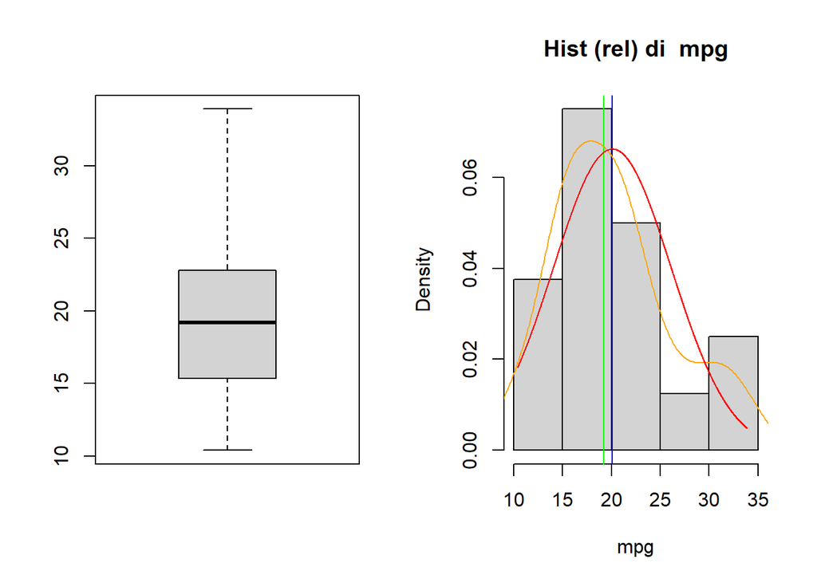

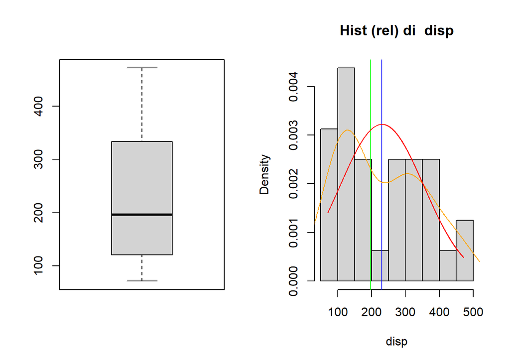

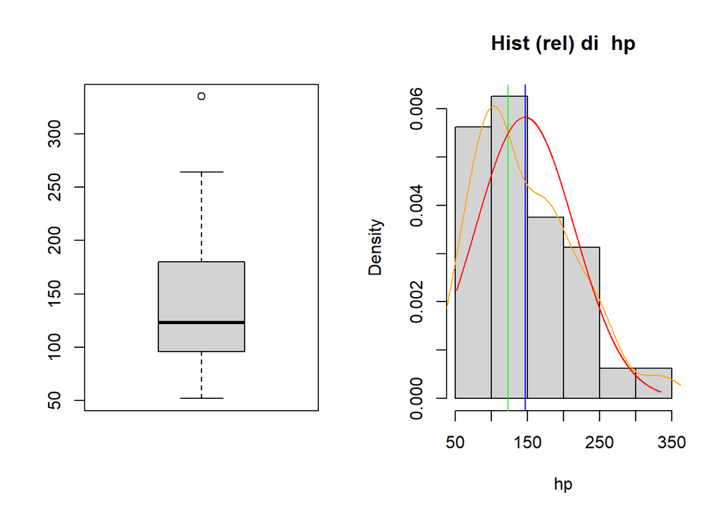

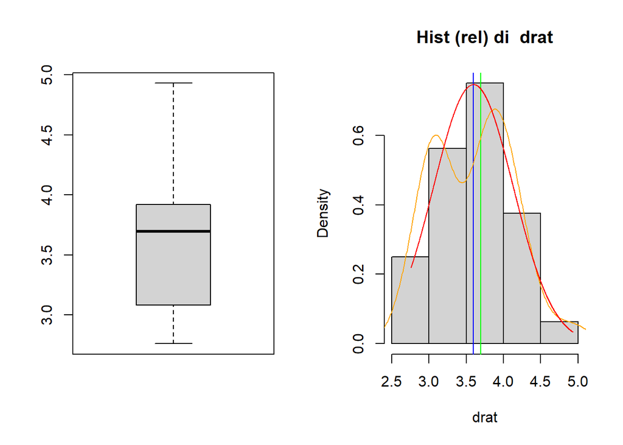

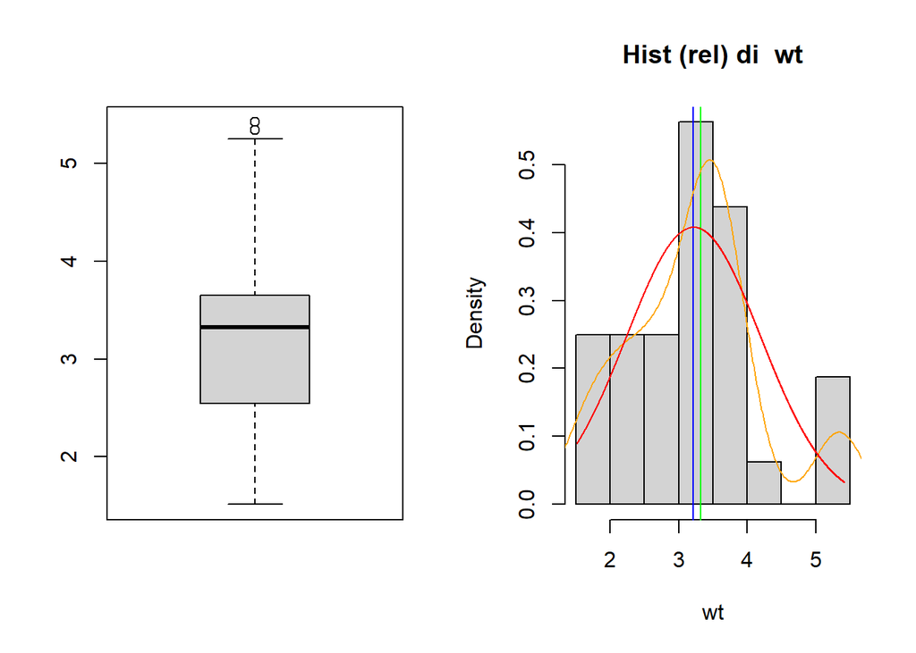

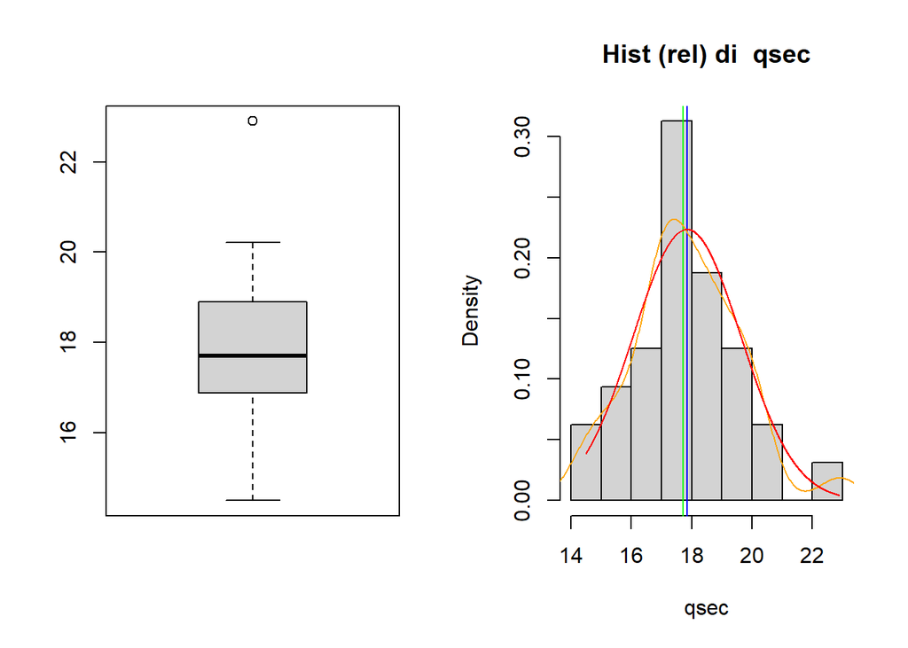

Delle variabili numeriche del dataset, nessuna ha una distribuzione riconducibile ad una normale, in quanto tutte presentano qualche forma di assimmetria e code pesanti (e/o outlyer).

qsec, se non fosse per alcuni outlyer sulle code sarebbe abbastanza normale.

disp e drat presentano una curva di densità con due picchi distinti (disp. in particolare).

```r
normality_check(mtcars2$mpg, stats=T, statsTest = T, normTest = T)
```

```
## [1] "NORMALITA' DI mtcars2$mpg"
## [1] "Media e Varianza del modello: "
## [1] 20.09062
## [1] 36.3241
## [1] "Ind. assimmetria e curtosi: "
## [1] 0.6404399
## [1] 2.799467
##
## Title:
##  D'Agostino Normality Test
##
## Test Results:
##   STATISTIC:
##     Chi2 | Omnibus: 2.7141
##     Z3  | Skewness: 1.6351
##     Z4  | Kurtosis: 0.2015
##   P VALUE:
##     Omnibus  Test: 0.2574
##     Skewness Test: 0.102
##     Kurtosis Test: 0.8403
##
## Description:
##  Tue Feb 01 15:47:56 2022 by user: Proprietario
```

```
##
##  One-sample Kolmogorov-Smirnov test
##
## data:  variable
## D = 1, p-value < 2.2e-16
## alternative hypothesis: two-sided
```

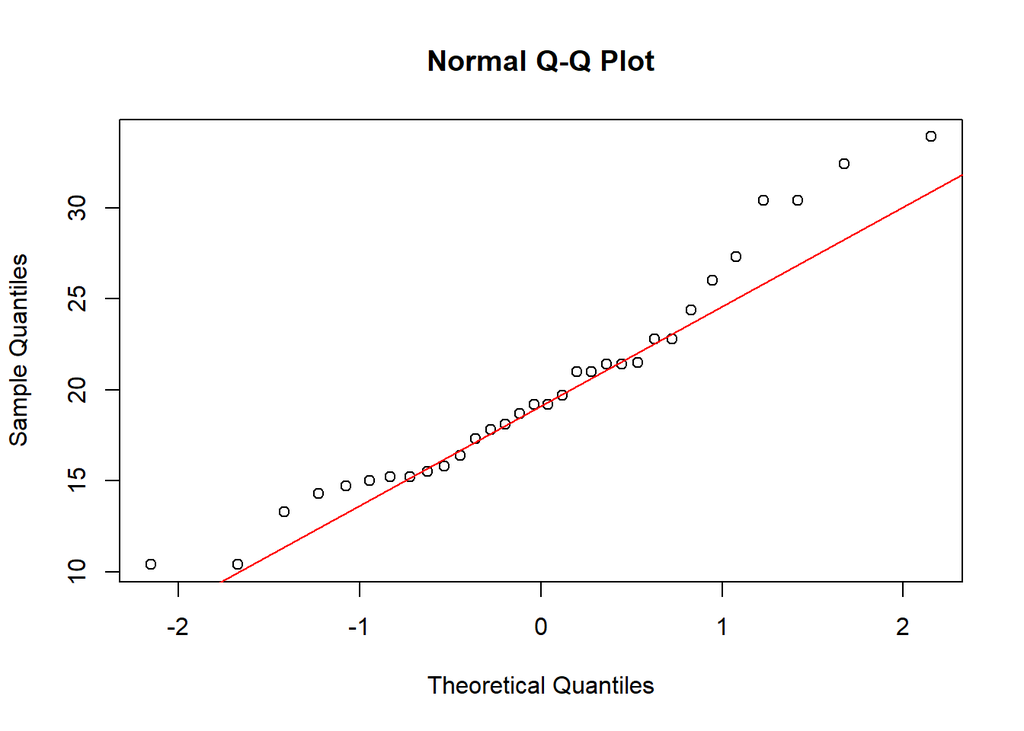

Nel confronto con i quantili teorici di una distrib normale, si oss. forti scostamenti sulle code.

Forse è il caso di considerare una trasformata.

```r
for (v in c("cyl", "gear", "carb")) {
  summary_categorial(v, data=mtcars2)
  # print("--------------------------------------")
  # print("")
}
```

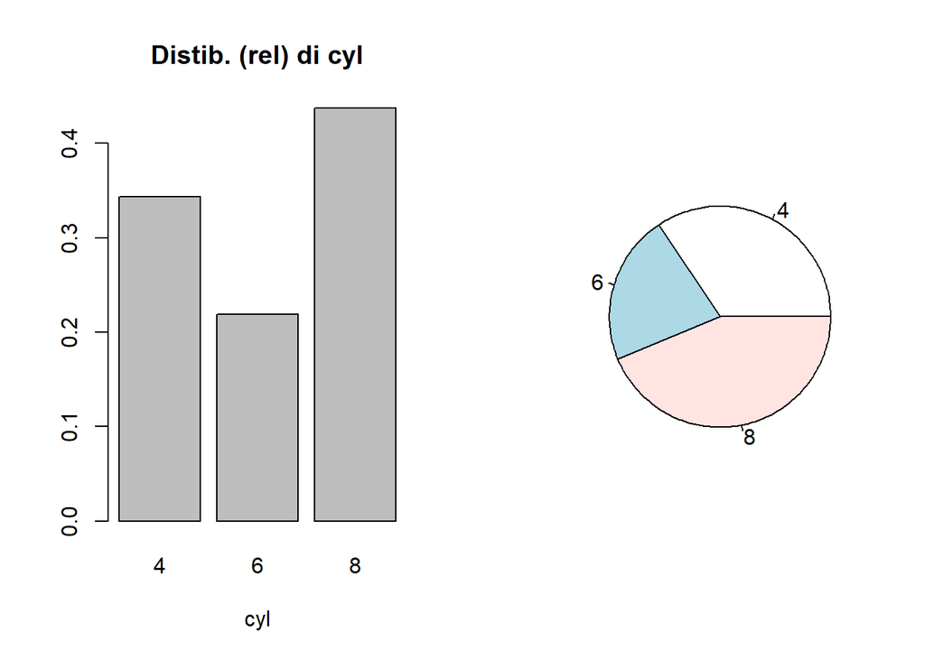

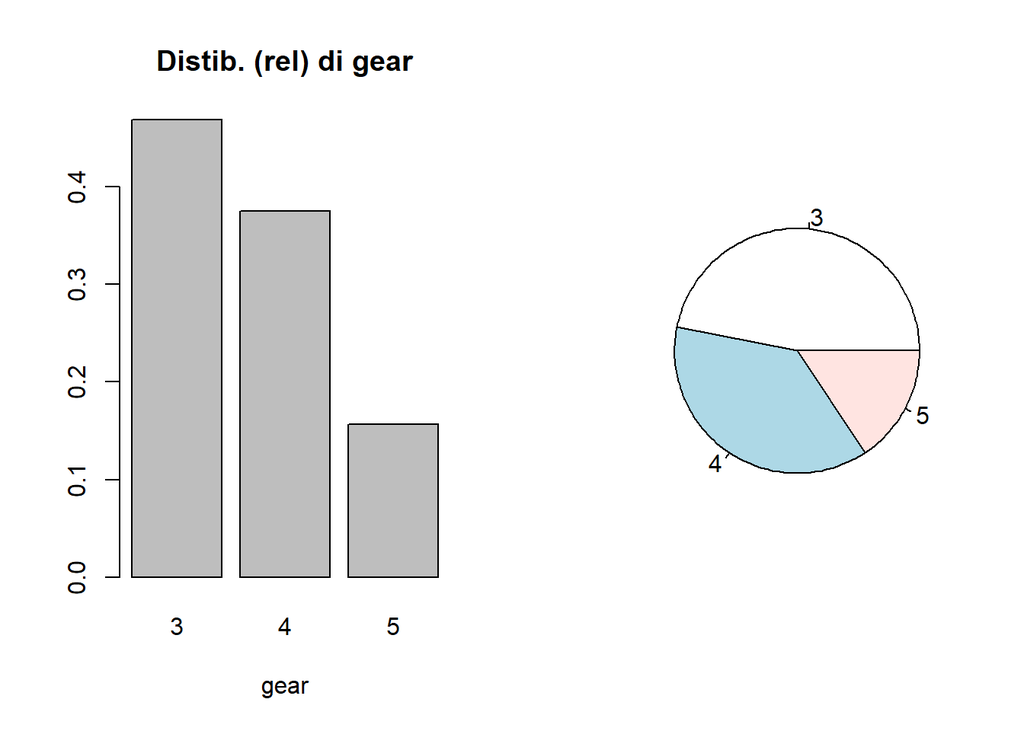

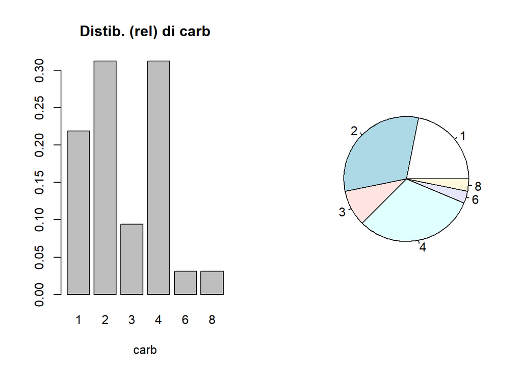

```r
for (v in c("vs", "am")) {
  summary_categorial(v, data=mtcars2)

}
```

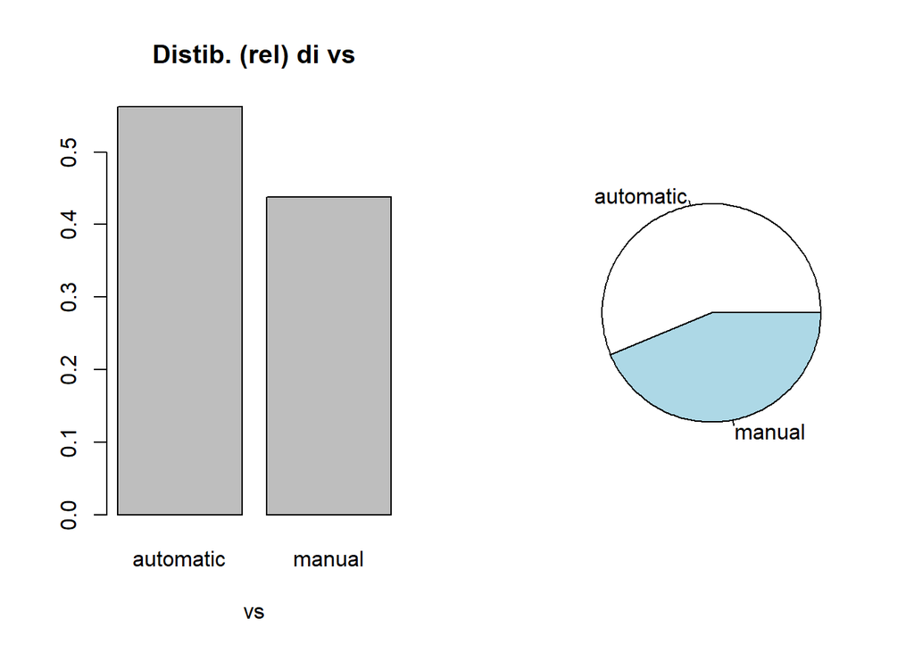

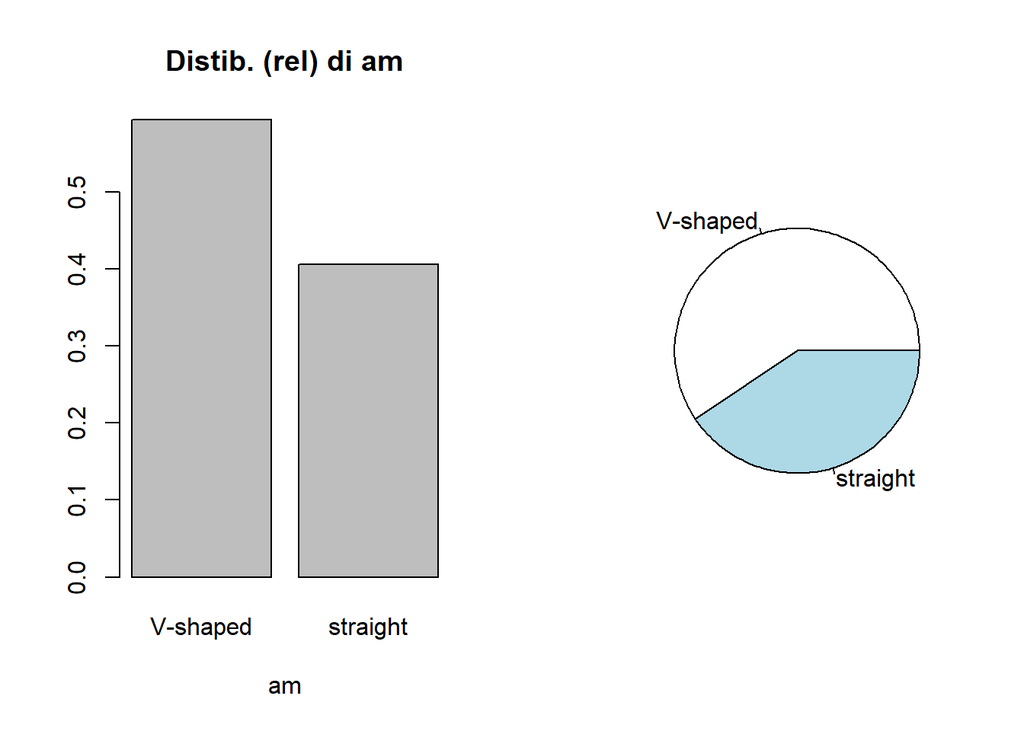

Per nessuna delle variabili categoriali ordinali si osserva una distribuzione uniforme. Un discorso analogo si può fare anche per le variabili binarie.

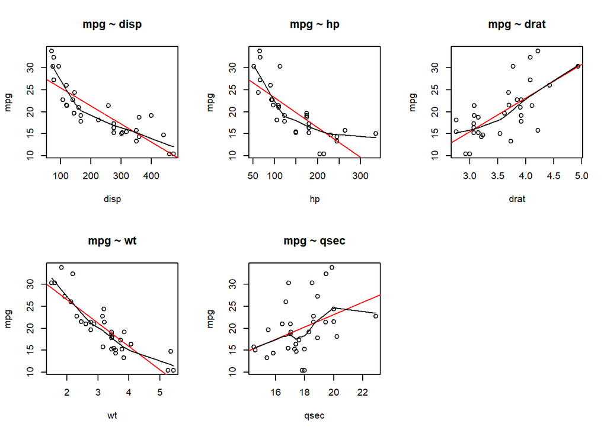

```r
par(mfrow=c(2,3))

for (v in c("disp", "hp", "drat", "wt", "qsec")) {
  correlation_check_num(v, "mpg", data=mtcars2)
}

par(mfrow=c(1,1))
```

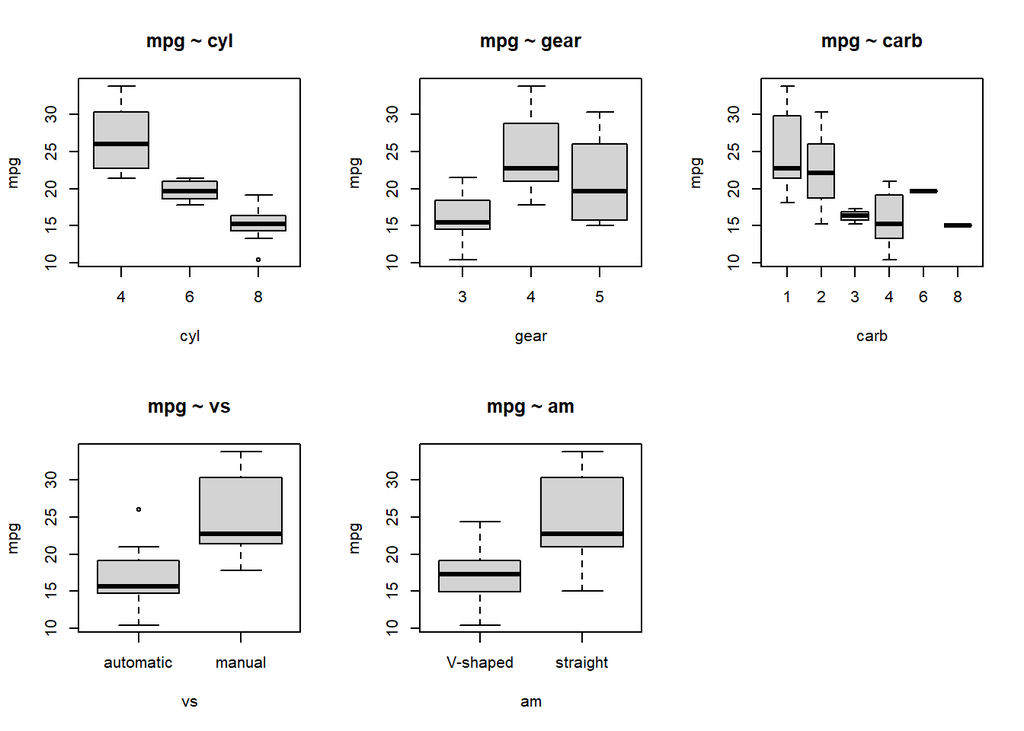

```r
par(mfrow=c(2,3))

for (v in c("cyl", "gear", "carb", "vs", "am")) {
  correlation_check_numfactor(v, "mpg", data=mtcars2)
}

par(mfrow=c(1,1))
```

Per le variabili numeriche disp, hp, drat e wt si osservano correlazioni abbastanza forti con mpg, ma forse non di tipo lineare. Per disp, hp e wt in particolare si suggerisce di valutare delle trasformate. Per drat si osserva maggiore propensione alla linearità ma anche maggiore variabilità.

La relazione tra mpg e qsec sembra incece essere piuttosto strana. Probabilmente c’è correlazione lineare ma anche molta variabilità.

Tutti i fattori sembrano avere un qualche tipo di influenza su mpg. Cyl in particolare sembra avere un’influenza di tipo lineare, pertanto forse sarebbe opportuno tornare a valutarlo come una variabile numerica discreta. Discorso analogo (anche se “rovinato” dai valori estremi) per carb.

## Analisi

After fitting the model `fit <- lm(mpg ∼ disp + hp + wt + drat, data=mtcars)`, the following outputs are obtained by the R commands `summary(fit)` and `plot(fit)`, respectively. Describe how to interpret these results, and then suggest how to proceed with further analyses.

```r
fit <- lm(mpg ∼ disp + hp + wt + drat, data=mtcars)
```

```r
summary(fit)
```

```
##
## Call:
## lm(formula = mpg ~ disp + hp + wt + drat, data = mtcars)
##
## Residuals:
##     Min      1Q  Median      3Q     Max
## -3.5077 -1.9052 -0.5057  0.9821  5.6883
##
## Coefficients:
##              Estimate Std. Error t value Pr(>|t|)
## (Intercept) 29.148738   6.293588   4.631  8.2e-05 ***
## disp         0.003815   0.010805   0.353  0.72675
## hp          -0.034784   0.011597  -2.999  0.00576 **
## wt          -3.479668   1.078371  -3.227  0.00327 **
## drat         1.768049   1.319779   1.340  0.19153
## ---
## Signif. codes:  0 '***' 0.001 '**' 0.01 '*' 0.05 '.' 0.1 ' ' 1
##
## Residual standard error: 2.602 on 27 degrees of freedom
## Multiple R-squared:  0.8376, Adjusted R-squared:  0.8136
## F-statistic: 34.82 on 4 and 27 DF,  p-value: 2.704e-10
```

- l’intercetta sembra avere un ruolo molto importante nella spiegazione della risposta.
- I coeffienti hp e wt hanno ottenuto un p-value discreto nella statistica test; è chiaro che tali coef. contribusiscano a spiegare, ma penso che ci sia margine di miglioramento.
- disp ha ottenuto un p-value decisamente troppo alto. Prima di scartarlo definitivamente, suggerirei di valutare una sua trasformazione. Anche per drat si può fare un discorso analogo.
- Si osserva, tutto sommato, un basso standard error sui residui (anche in confronto alla dev. std della risposta).

```r
sd(mtcars$mpg)
```

```
## [1] 6.026948
```

- Il coefficente $R^2$ - sia nella sua versione normale che in quella corretta - indicano che una buona parte della varianza della risposta è spiegata dal modello (più dell’80%).
- Dal p-value ottenuto per la statistica F, si può dire che il modello contribuisce a spiegare la varianza della variabile risposta.

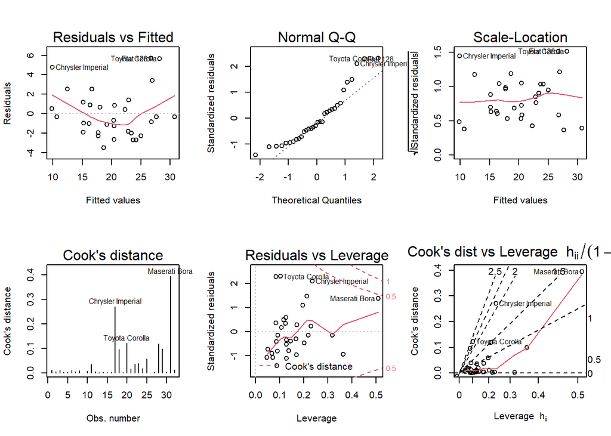

```r
par(mfrow=c(2,3))
plot(fit, which = (1:6))
```

```r
par(mfrow=c(1,1))
```

- dal grafico dei residui, si osserva la presenza di una strana relazione tra i residui e i valori stimati; in particolare, per i valori centrali di mpg si osservano residui contenuti o negativi, per le code invece si osservano alcuni residui particolarmente alti.
- dal confronto con i quantili teorici, si notano importanti discostamenti sulle code.
- dal grafico dei residui standardizzati, si osserva una variabilità tutto sommato uniforme, che aumenta leggemente sulle code.
- nessun punto presenta una distanza di cook elevata in senso assoluto, detto ciò ci sono almeno due punti con distanza di cook superiore a quella degli altri. Tali punti probabilmente sono leve, detto ciò non si consiglia di rimuoverli dal modello, vista la dimensione contenuta dei dati d’addestramento.

Per proseguire si suggersice di:

- valutare per tutti e quattro i regressori numerici scale differenti, in quanto durante l’EDA si sono evidenziate relazioni forti ma non di tipo strettamente lineare.

```r
par(mfrow=c(2,3))

for (v in c("disp", "hp", "drat", "wt")) {
  correlation_check_num(v, "mpg", data=mtcars2, stats = T, statsTest = T)
}
```

```
## [1] "ANALISI PRELIMINARE DELLA CORRELAZIONE mpg ~ disp"
## [1] "Covarianza: "
## [1] -633.0972
## [1] "Indice di Pearson e di Spearman: "
## [1] -0.8475514
## [1] -0.7681311
```

```
##
##  Kendall's rank correlation tau
##
## data:  x and y
## z = -6.1083, p-value = 1.007e-09
## alternative hypothesis: true tau is not equal to 0
## sample estimates:
##        tau
## -0.7681311
```

```
## [1] "ANALISI PRELIMINARE DELLA CORRELAZIONE mpg ~ hp"
## [1] "Covarianza: "
## [1] -320.7321
## [1] "Indice di Pearson e di Spearman: "
## [1] -0.7761684
## [1] -0.7428125
```

```
##
##  Kendall's rank correlation tau
##
## data:  x and y
## z = -5.871, p-value = 4.332e-09
## alternative hypothesis: true tau is not equal to 0
## sample estimates:
##        tau
## -0.7428125
```

```
## [1] "ANALISI PRELIMINARE DELLA CORRELAZIONE mpg ~ drat"
## [1] "Covarianza: "
## [1] 2.195064
## [1] "Indice di Pearson e di Spearman: "
## [1] 0.6811719
## [1] 0.4645488
```

```
##
##  Kendall's rank correlation tau
##
## data:  x and y
## z = 3.6747, p-value = 0.0002382
## alternative hypothesis: true tau is not equal to 0
## sample estimates:
##       tau
## 0.4645488
```

```
## [1] "ANALISI PRELIMINARE DELLA CORRELAZIONE mpg ~ wt"
## [1] "Covarianza: "
## [1] -5.116685
## [1] "Indice di Pearson e di Spearman: "
## [1] -0.8676594
## [1] -0.7278321
```

```
##
##  Kendall's rank correlation tau
##
## data:  x and y
## z = -5.7981, p-value = 6.706e-09
## alternative hypothesis: true tau is not equal to 0
## sample estimates:
##        tau
## -0.7278321
```

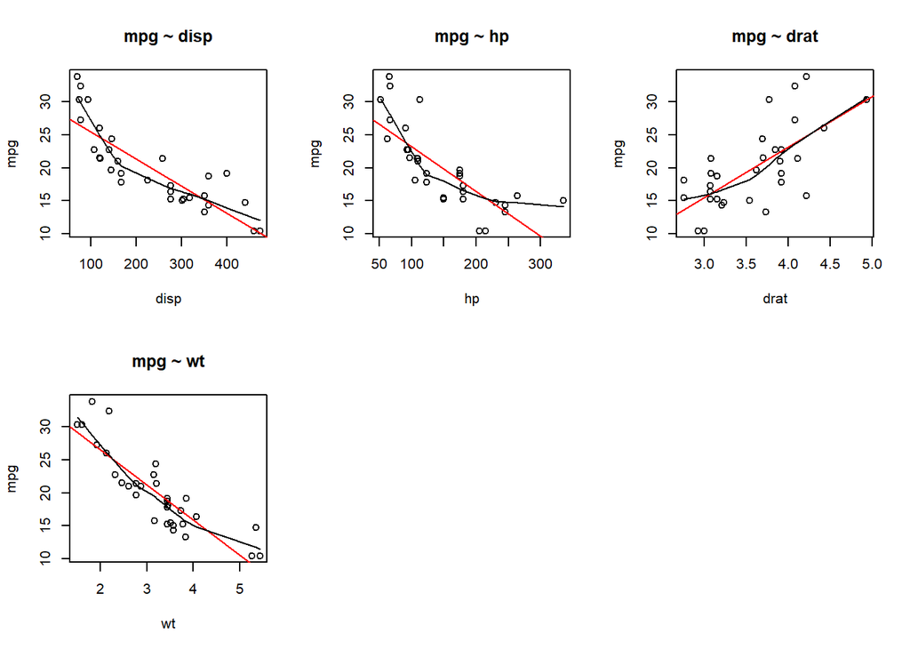

```r
par(mfrow=c(1,1))
```

- valutare di introdurre nel modello anche alcuni fattori. In particolare, si suggerisce di sperimentare con cyl.
- una volta individuate le scale più corrette, provare a creare e confrontare diversi modelli più o meno sofisticati (effettuando confronti con ANOVA e con i criteri AIC e BIC). Nel processo, si suggerisce di confrontarsi con un esperto del settore (e di estendere l’EDA) per individuare eventuali collinearità.